# Instituto Tecnologico de Aguascalientes

# Departamento: Sistemas y Computacion

# carrera: Ingenieria en ciberseguridad

## Materia: Estructura de datos

## Maestro:Dr. Fransisco Javier Luna Rosas

## Alumno: Aracely Mas Flores

### Semestre: Agosto_Diciembre del 2026

## Estructuras de Datos Estáticas Lineales

### Las estructuras de datos lineales son aquilles en las que los elementos se organizan uno después de otro, formando una secuencia

## ¿Qué es una Matriz Estática?

### Una matriz estática es una estructura de datos que tiene un número fijo de filas y columnas, definidas desde el momento que se crean.

## Imágen Digital

### Digitalmente, una imágen puede representarse como una matriz especialmente cuando hablamos de procesamiento de imágenes.

# Practica No.8

### En esta practica implementarmos un programa en Python para convertir una imagen en escala de grises

## Paso 1: Importar librerias

```python
from PIL import Image
import matplotlib.pyplot as plt
```

## Paso 2: Cargar imagen

```python
imagen = Image.open("C:/Users/mayri/OneDrive/Escritorio/Estructura-de-Datos/gato.jpg")
```

## Paso 3:Obtener las dimensiones de la imagen

```python
ancho, alto = imagen.size
```

```python
escalaGrises = Image.new("RGB", (ancho, alto))
```

## Paso 5: Recorrer la matriz de pixeles

```python
for x in range(ancho):
    for y in range(alto):
        pixel = imagen.getpixel((x, y))
        promedio = int(sum(pixel) / 3)
        escalaGrises.putpixel((x, y), (promedio, promedio, promedio))
```

```python
escalaGrises.save("C:/Users/mayri/OneDrive/Escritorio/Estructura-de-Datos/gato_grises.png")
imagen_grises = Image.open("C:/Users/mayri/OneDrive/Escritorio/Estructura-de-Datos/gato_grises.png")
```

## Paso 7: Mostrar ambas imagenes con matplotlib

```
(np.float64(-0.5), np.float64(575.5), np.float64(323.5), np.float64(-0.5))
```

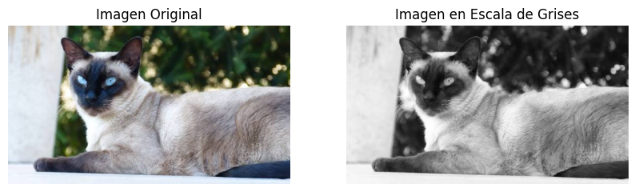

```python
plt.figure(figsize=(10, 5))

plt.subplot(1, 2, 1)
plt.imshow(imagen)
plt.title("Imagen Original")
plt.axis('off')

plt.subplot(1, 2, 2)
plt.imshow(imagen_grises)
plt.title("Imagen en Escala de Grises")
plt.axis('off')
```

## Referencias

### 1. Araujo, SL, Martínez, UR, Rodríguez, AM (2011). Programación y estructuras de datos avanzadas. España: Centro de estudios. Ramón Areces.

### 2. Garrido Carrillo, A. & Valdivia Joaquín, F. (2006). Abstracción y estructura de datos en C++: (ed.). Publicaciones Delta.

### 3. Malik, DS (2013). Estructuras de datos con C++: (2 ed.). Aprendizaje Cengage.

### 4. Google. (2026). Gemini (Versión de agosto de 2026) [Modelo de lenguaje grande]. https://gemini.google.com

### 5. imagenes en python (Pillow, 2026) https://pillow.readthedocs.io/en/stable/ (Ultimo acceso Septiembre de 2026)